# Reproducible Research - Assignment 1

Daniel Bell

### Step 1: Loading and preprocessing the data

Here the ‘activity’ dataset is loaded into R and stored in the variable ‘activityData’. We assume here that the data has already been downloaded into the correct directory.

```r
activityData <- read.csv("C:/Data/Coursera/Reproducible Research/activity.csv")
```

### Step 2: What is mean total number of steps taken per day?

First, we create a new data frame consisting of the total number of steps taken for each day. The ‘plyr’ package is installed in order make use of the ‘ddply’ function.

```r
library(plyr)
totalStepsDay<- ddply(activityData,~date,summarise,sum=sum(steps))
```

Next a histogram has been created containing the total number of steps for each day.

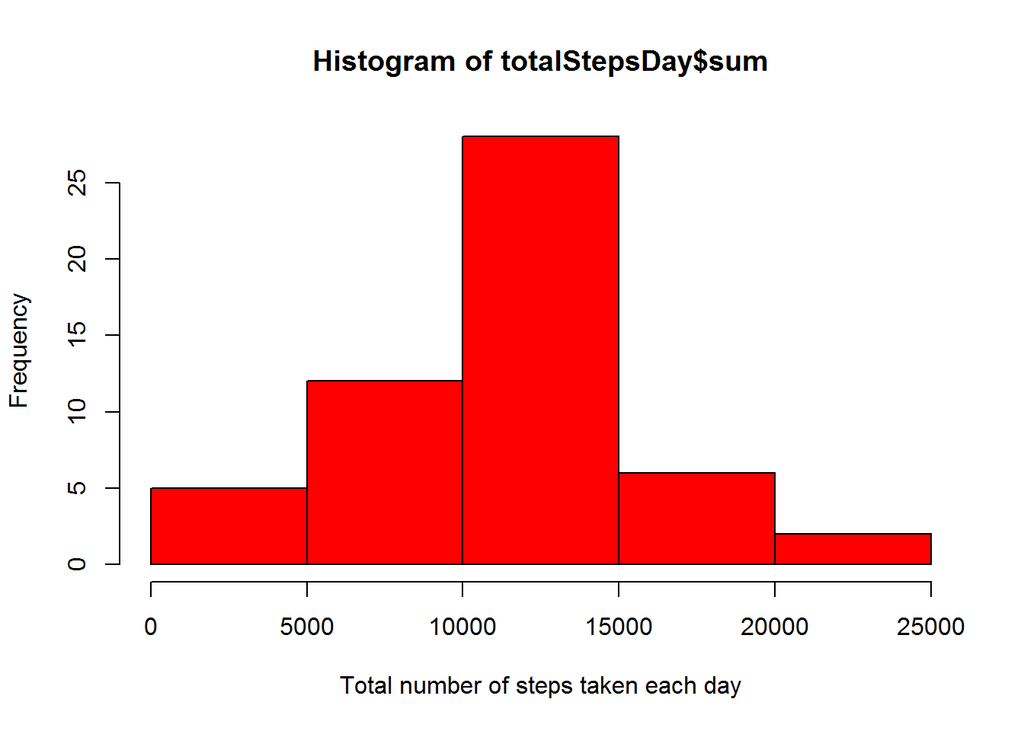

```r
hist(totalStepsDay$sum, breaks=5, xlab="Total number of steps taken each day", col="red")
```

Finally the mean number of steps taken per day is calculated with the output reported below.

```r
ddply(totalStepsDay,~date,summarise,mean=mean(sum),median=median(sum))
```

```
##          date  mean median
## 1  2012-10-01    NA     NA
## 2  2012-10-02   126    126
## 3  2012-10-03 11352  11352
## 4  2012-10-04 12116  12116
## 5  2012-10-05 13294  13294
## 6  2012-10-06 15420  15420
## 7  2012-10-07 11015  11015
## 8  2012-10-08    NA     NA
## 9  2012-10-09 12811  12811
## 10 2012-10-10  9900   9900
## 11 2012-10-11 10304  10304
## 12 2012-10-12 17382  17382
## 13 2012-10-13 12426  12426
## 14 2012-10-14 15098  15098
```

[output cut: 47 more lines]

### Step 3: What is the average daily activity pattern?

Below is the code that plots a timeseries graph showing the average number of steps taken in each 5 minute interval per day.

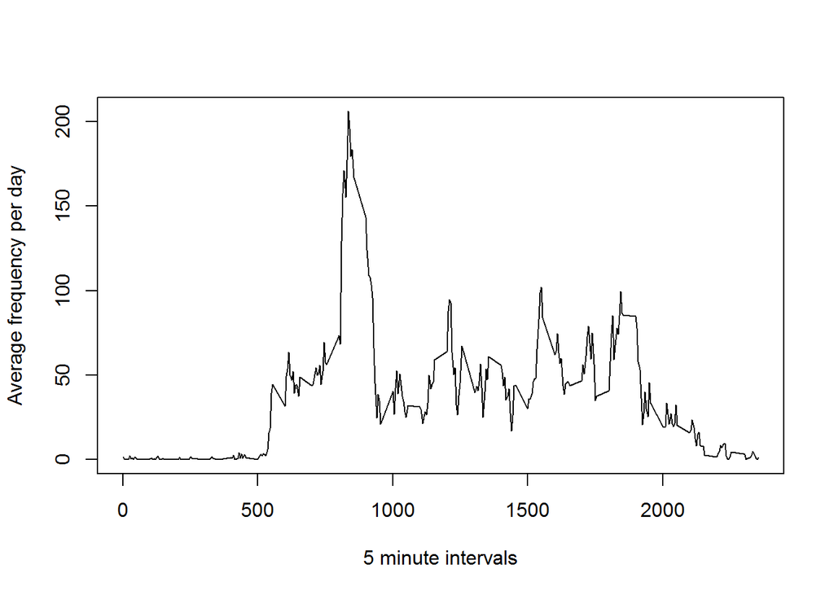

```r
totalStepsInterval<- ddply(activityData,~interval,summarise,mean=mean(steps, na.rm = TRUE))
plot(x=totalStepsInterval$interval, y=totalStepsInterval$mean, xlab="5 minute intervals", ylab="Average frequency per day", type="l")
```

To figure out which five minute interval contains the highest average number of steps, the following code is run with the output reported below.

```r
totalStepsInterval[which.max(totalStepsInterval$mean), 1]
```

```
## [1] 835
```

### Step 4: Imputing missing values

To begin the total number of missing values found aacross teh whole dataset was calculated and is reported below.

```r
sum(is.na(activityData$steps))
```

```
## [1] 2304
```

To impute missing data it was decided that the average 5-minute interval total number of steps value would be used. This was chosen as there were a number of days within the dataset with no data at all, meaning it would be impossible to simply calculate the mean for these days and add this into the missing values.

This is then saved in a new dataset called ‘completeData’.

```r
completeData <- activityData
naIndices <- which(is.na(completeData$steps))
for (i in naIndices) {
    completeData$steps[i] <- with(totalStepsInterval, mean[interval == completeData$interval[i]])
}
```

The two tables highlight the differences between the upper table ‘activityData’ and the lower table ‘completeData’.

```r
head(activityData)
```

```
##   steps       date interval
## 1    NA 2012-10-01        0
## 2    NA 2012-10-01        5
## 3    NA 2012-10-01       10
## 4    NA 2012-10-01       15
## 5    NA 2012-10-01       20
## 6    NA 2012-10-01       25
```

```r
head(completeData)
```

```
##       steps       date interval
## 1 1.7169811 2012-10-01        0
## 2 0.3396226 2012-10-01        5
## 3 0.1320755 2012-10-01       10
## 4 0.1509434 2012-10-01       15
## 5 0.0754717 2012-10-01       20
## 6 2.0943396 2012-10-01       25
```

To complete this step we create another histogram for the newly created ‘completeData’ dataset.

```r
totalStepsDayComplete<- ddply(completeData,~date,summarise,sum=sum(steps))
```

Next a histogram has been created containing the total number of steps for each day.

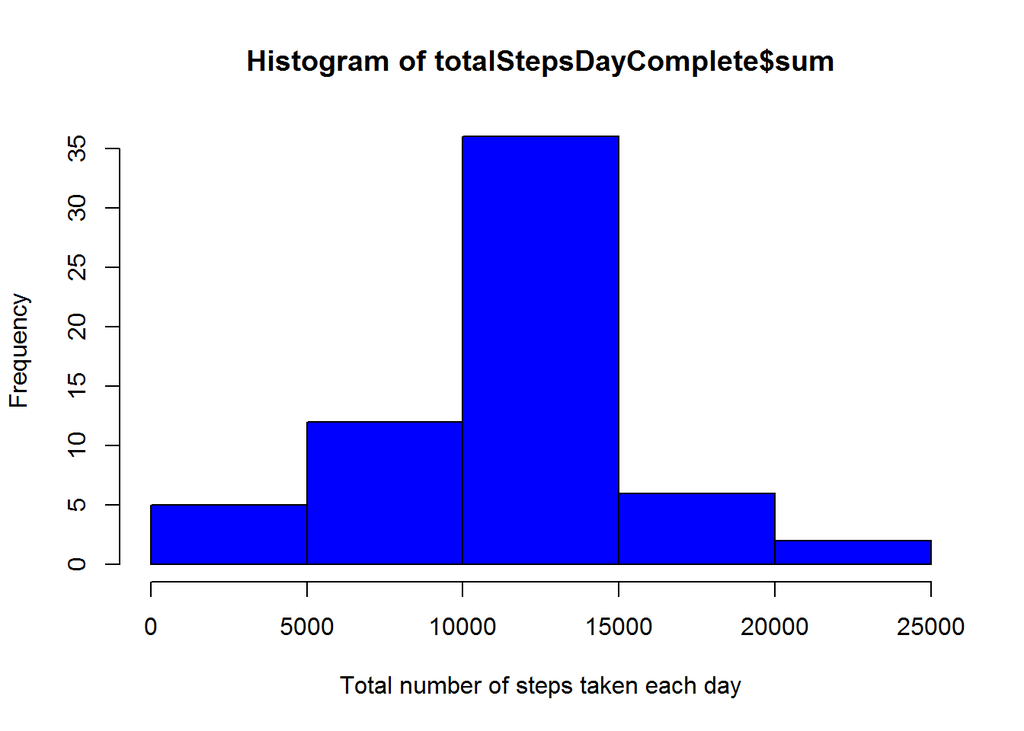

```r
hist(totalStepsDayComplete$sum, breaks=5, xlab="Total number of steps taken each day", col="blue")
```

### Step 5: Are there differences in activity patterns between weekdays and weekends?

To look at weekday and weekend patterns we first add a new factor variable to the dataset indictating whether a given day is on the weekend or a weekday.

```r
library(timeDate)
completeData$isWeekday <- isWeekday(completeData$date, wday=1:5)
```

Next the average number of steps taken across each 5 minute interval is calculated for both weekdays and weekends. This is then plotted to the panel plot below, the top plot being weekdays and the bottom plot being weekends.

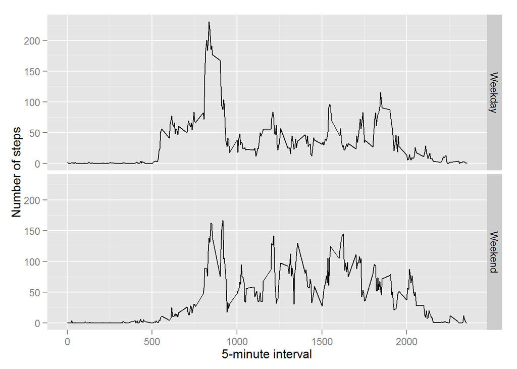

```r
library(ggplot2)
averages <- aggregate(steps ~ interval + isWeekday, data=completeData, mean)
averages$isWeekday <- gsub("TRUE", "Weekday", averages$isWeekday)
averages$isWeekday <- gsub("FALSE", "Weekend", averages$isWeekday)
ggplot(averages, aes(interval, steps)) + geom_line() + facet_grid(isWeekday ~ .) +
    xlab("5-minute interval") + ylab("Number of steps")
```